# STAT 440 Statistical Data Management - Fall 2021

## Homework01

### Due: Monday September 13, 2021 11:59 pm US Central Time

#### Created by Course Staff

Grading Rubric (per question):  
2 points if complete and correct  
1 point if incomplete or incorrect  
0 points if no attempt made

**Retrieving your work**

This and all future homework .md files are written in Markdown. The .md file is rendered as an .html file for easier viewing. This and all future homework assignments are located in the **homework** directory within the **stat440-fa21-course-content** repo, i.e. **stat440-fa21-course-content/homework** in GHE. It is always recommended that you **pull** (or refresh) the **stat440-fa21-course-content** repo to ensure that you have the most updated version of all course content including the homework assignments. After pulling (or refreshing) the **stat440-fa21-course-content** repo, the homework file will be in the homework directory. Once you have accessed the .md file, copy all text from the .md file and paste all text into your reproducible document file (either .Rmd or .ipynb file).

**Submitting your work**

In your individual student repo (named as your netID), you are to submit *two* files:

1. Your reproducible document file (either .Rmd or .ipynb file) which should be saved as homework##-netID.Rmd or homework##-netID.ipynb depending on your preferred software. For example, my homework 01 file would be saved as homework01-kinson2.Rmd.
2. Your rendered reproducible document file (.html) which should be saved as homework##-netID.html. For example, my homework 01 file would be saved as homework01-kinson2.html.

**Do not place your files in a sub-directory (or folder).** You have an unlimited number of submissions, but only the latest proper submission (commit and push) will be viewed and graded. You are allowed to only use one software language per homework file. This means that you cannot mix software languages (R and Python) in one single homework file. **Remember the .Rmd (or .ipynb) file needs to render properly to .html before submitting.**

Undergraduates are expected to complete the problems **#1-#8**. Graduate students are expected to complete all problems.

**The following problems should be completed by you as an individual. If any problem asks you a particular question, be sure to answer it completely (with code, written sentences, or both). Written sentences should not appear in code chunks or code cells. Written sentences should appear in Markdown syntax unless specifically stated otherwise.**

*Do not change anything in this file above the double line. Doing so will prevent your homework from being graded.*

### Use only one programming language for this entire homework assignment. Use the URLs to access the data (if any). No local files allowed.

**#1** (Markdown) Using Markdown syntax, create a numbered list with your first name in normal text as the first item and your last name in bold text as the second item.

1. Haofei
2. **Xu**

**#2** (Personal survey, Markdown) Select all of the following that you feel are must-haves in order for your learning to be successful.

- i. lecture videos
- ii. course notes
- iii. assignments
- iv. assignment solutions
- v. feedback on the assignments
- vi. office hours
- vii. discussions with classmates

**#3** (Personal survey, Markdown) What is the highest numbered STAT course you have taken prior to this semester? *For example, STAT 510 is higher than STAT 480.*

**STAT 420**

**#4** (Syllabus, Markdown) All assignments are assumed to be in which time zone?

**Central Time**

**#5** (Syllabus, Markdown) In a Markdown unordered list, write the names of the course staff.

- Instructor - Christopher Kinson (kinson2@illinois.edu)
- Teaching Assistant (TA) - Jim Yan (yiciyan2@illinois.edu)
- Teaching Assistant (TA) - Jaideep Mahajan (jaideep3@illinois.edu)

**#6** (Prior knowledge, Markdown) Consider the information in the image below and the image itself as a data set. Make 2 Markdown lists: one list contains 3 things you observe about the data set, and the other list contains 3 questions about the data set (i.e. things you want to know about the data).

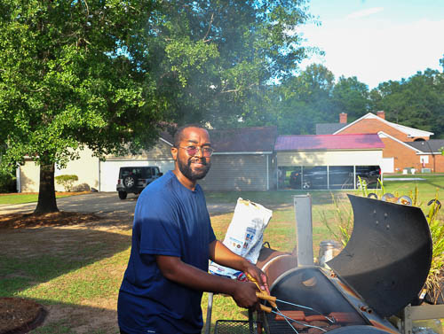

pic01

### Things you observe about the data set

- There is one person (Prof. Kinson) on this image
- There is one grill on this image
- There is two cars on this image

### Things you want to know about the data

- How many sausages there?
- How many calories are there in one sausage?
- How much joule of heat produced by the coals?

**#7** (Prior knowledge, Markdown) Considering the image in **Problem 6** and using Markdown, create a Markdown table that shows how you would organize the data information into tabular form with at least 10 rows and at least 2 columns with column names. *Your table should have a header row that contains the column names and should be 10 rows (excluding header) and 2 columns.*

[output not shown]

**#8** (Prior knowledge, Markdown) Consider the information in the image below and the image itself as a data set. Make 2 Markdown lists: one list contains 3 things you observe about the data set, and the other list contains 3 questions about the data set (i.e. things you want to know about the data).

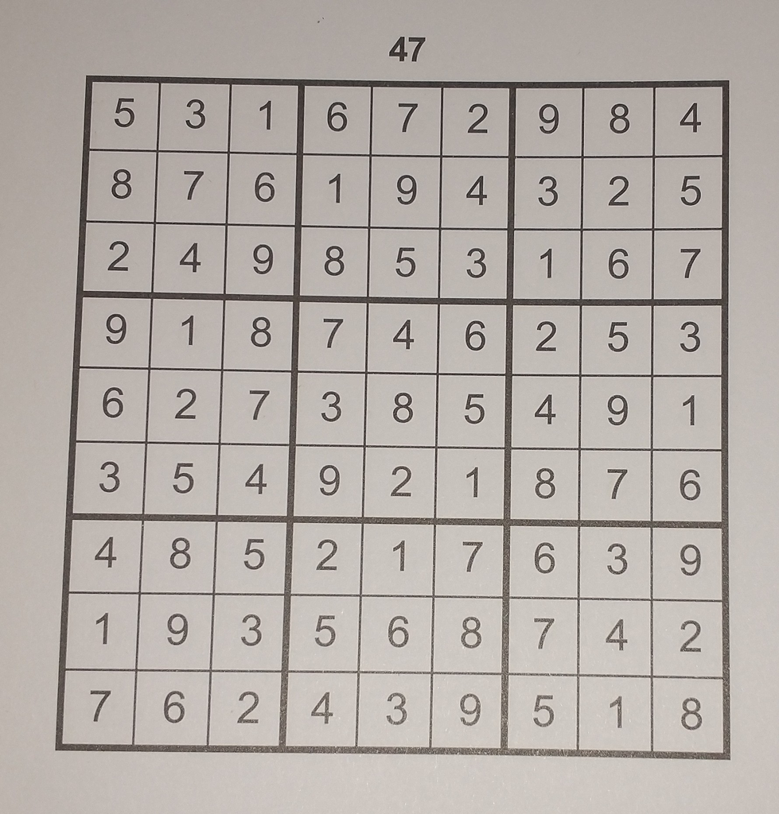

pic02

### Things you observe about the data set

- Each row of the grid has digits from 1 to 9
- Each column of the grid has digits from 1 to 9
- Each of the 9 subgrids contains digits from 1 to 9

### Things you want to know about the data

- How many such filled grids can be, satisfying all these rules above?
- What does the number 47 mean above the grid?
- Does the sum of one subgird inderdependently relate to other subgrids?

**#9** (Prior knowledge, Markdown) Now, imagine that the data and information in the image in **Problem 8** could be put into tabular form (with rows and columns). What would be the field names? **You must include at least two field names.**

**#10** (Prior knowledge, Markdown) Considering your idea for an organized tabular form of the data in **Problem 9**, describe:

- a kind of data analysis that is sensible for this data set
- what information is needed to help improve the data so that more analysis can be done.

**Your answer for this problem should be written in complete sentences that follows Markdown syntax.**